# Objective

#### Analyse the performance in IPL matches over past years

# Download and Prep the Data: 1 Mark

#### Import the libraries needed

```python
import pandas as pd
import matplotlib.pyplot as plt
import seaborn as sns
import numpy as np
```

#### Load data and store in dataframe

```python
df1=pd.read_csv("dvi-a2-ps4-data1.csv")
df2=pd.read_csv("dvi-a2-ps4-data2.csv")
```

#### Display the first five items in the datasets.

```python
print(df1.head(5))
```

```
   match_id  inning         batting_team                 bowling_team  over  \
0         1       1  Sunrisers Hyderabad  Royal Challengers Bangalore     1
1         1       1  Sunrisers Hyderabad  Royal Challengers Bangalore     1
2         1       1  Sunrisers Hyderabad  Royal Challengers Bangalore     1
3         1       1  Sunrisers Hyderabad  Royal Challengers Bangalore     1
4         1       1  Sunrisers Hyderabad  Royal Challengers Bangalore     1

   ball    batsman non_striker    bowler  is_super_over  ...  bye_runs  \
0     1  DA Warner    S Dhawan  TS Mills              0  ...         0
1     2  DA Warner    S Dhawan  TS Mills              0  ...         0
2     3  DA Warner    S Dhawan  TS Mills              0  ...         0
3     4  DA Warner    S Dhawan  TS Mills              0  ...         0
4     5  DA Warner    S Dhawan  TS Mills              0  ...         0

   legbye_runs  noball_runs  penalty_runs  batsman_runs  extra_runs  \
0            0            0             0             0           0
1            0            0             0             0           0
2            0            0             0             4           0
3            0            0             0             0           0
4            0            0             0             0           2

   total_runs  player_dismissed dismissal_kind fielder
0           0               NaN            NaN     NaN
1           0               NaN            NaN     NaN
2           4               NaN            NaN     NaN
3           0               NaN            NaN     NaN
4           2               NaN            NaN     NaN

[5 rows x 21 columns]
```

```python
print(df2.head(5))
```

```
   id  season       city        date                        team1  \
0   1    2017  Hyderabad  2017-04-05          Sunrisers Hyderabad
1   2    2017       Pune  2017-04-06               Mumbai Indians
2   3    2017     Rajkot  2017-04-07                Gujarat Lions
3   4    2017     Indore  2017-04-08       Rising Pune Supergiant
4   5    2017  Bangalore  2017-04-08  Royal Challengers Bangalore

                         team2                  toss_winner toss_decision  \
0  Royal Challengers Bangalore  Royal Challengers Bangalore         field
1       Rising Pune Supergiant       Rising Pune Supergiant         field
2        Kolkata Knight Riders        Kolkata Knight Riders         field
3              Kings XI Punjab              Kings XI Punjab         field
4             Delhi Daredevils  Royal Challengers Bangalore           bat

   result  dl_applied                       winner  win_by_runs  \
```

[output cut: 19 more lines]

#### Find out what type of variables you are dealing with. This will help you find the right visualization method for that variable.</p>

```python
print(df1.dtypes)

# Get the data types in the dataset
unique_data_types = df1.dtypes.unique()

# Print the different data types
print("\n")
print("Data Types in the Dataset:")
for data_type in unique_data_types:
    print(data_type)
```

```
match_id             int64
inning               int64
batting_team        object
bowling_team        object
over                 int64
ball                 int64
batsman             object
non_striker         object
bowler              object
is_super_over        int64
wide_runs            int64
bye_runs             int64
legbye_runs          int64
noball_runs          int64
penalty_runs         int64
batsman_runs         int64
extra_runs           int64
total_runs           int64
player_dismissed    object
dismissal_kind      object
fielder             object
dtype: object


Data Types in the Dataset:
int64
object
```

```python
print(df2.dtypes)

# Get the data types in the dataset
unique_data_types = df2.dtypes.unique()

# Print the different data types
print("\n")
print("Data Types in the Dataset:")
for data_type in unique_data_types:
    print(data_type)
```

```
id                   int64
season               int64
city                object
date                object
team1               object
team2               object
toss_winner         object
toss_decision       object
result              object
dl_applied           int64
winner              object
win_by_runs          int64
win_by_wickets       int64
player_of_match     object
venue               object
umpire1             object
umpire2             object
umpire3            float64
dtype: object


Data Types in the Dataset:
int64
object
float64
```

#### Find out how many entries there are in the datasets.

```python
print("Number of entries in dataset1",df1.shape)
print("Number of entries in dataset2",df2.shape)
```

```
Number of entries in dataset1 (150460, 21)
Number of entries in dataset2 (636, 18)
```

#### Find out total number of distinct cities, teams, seasons, and venues associated in this data.

```python
#print(df2['city'].unique())
#print(df2['team1'].unique())
#print(df2['team2'].unique())
#print(df2['season'].unique())
#print(df2['venue'].unique())

#Correting the spelling error of the team 'Rising Pune Supergiant'
df2.replace('Rising Pune Supergiant' , 'Rising Pune Supergiants' , inplace = True)

# Find the total number of distinct cities
distinct_cities = df2['city'].nunique()

# Find the total number of distinct teams
distinct_teams = pd.concat([df2['team1'], df2['team2']]).nunique()

# Find the total number of distinct seasons
distinct_seasons = df2['season'].nunique()

# Find the total number of distinct venues
distinct_venues = df2['venue'].nunique()

# Print the results
print("Total number of distinct cities:", distinct_cities)
print("Total number of distinct teams:", distinct_teams)
print("Total number of distinct seasons:", distinct_seasons)
print("Total number of distinct venues:", distinct_venues)
```

```
Total number of distinct cities: 30
Total number of distinct teams: 13
Total number of distinct seasons: 10
Total number of distinct venues: 35
```

#### Clean up data. Remove unnecessary columns. Clearly mention the data cleaning steps and reasoning in the markdown cell.

```python
df1.isna().sum()
```

```
match_id                 0
inning                   0
batting_team             0
bowling_team             0
over                     0
ball                     0
batsman                  0
non_striker              0
bowler                   0
is_super_over            0
wide_runs                0
bye_runs                 0
legbye_runs              0
noball_runs              0
penalty_runs             0
batsman_runs             0
extra_runs               0
total_runs               0
player_dismissed    143022
dismissal_kind      143022
fielder             145091
dtype: int64
```

```python
df2.isna().sum()
```

```
id                   0
season               0
city                 7
date                 0
team1                0
team2                0
toss_winner          0
toss_decision        0
result               0
dl_applied           0
winner               3
win_by_runs          0
win_by_wickets       0
player_of_match      3
venue                0
umpire1              1
umpire2              1
umpire3            636
dtype: int64
```

```python
# umpire3 columns with many missing values and other two columns umpire1,umpire2 also less useful for the given questions , so it can be removed.
df2.drop(labels = ['umpire3','umpire2','umpire1'], axis = 1, inplace = True)
# player_dismissed,dismissal_kind,fielder columns with many missing values and it can be removed.
df1.drop(labels = ['player_dismissed','dismissal_kind','fielder'], axis = 1, inplace = True)
```

```python
df2.isna().sum()
```

```
id                 0
season             0
city               7
date               0
team1              0
team2              0
toss_winner        0
toss_decision      0
result             0
dl_applied         0
winner             3
win_by_runs        0
win_by_wickets     0
player_of_match    3
venue              0
dtype: int64
```

```python
df1.isna().sum()
```

```
match_id         0
inning           0
batting_team     0
bowling_team     0
over             0
ball             0
batsman          0
non_striker      0
bowler           0
is_super_over    0
wide_runs        0
bye_runs         0
legbye_runs      0
noball_runs      0
penalty_runs     0
batsman_runs     0
extra_runs       0
total_runs       0
dtype: int64
```

```python
# calculates the total number of duplicate rows in the DataFrame
df1_dup = df1.duplicated().sum()
df2_dup = df2.duplicated().sum()
#removes if any duplicate rows present
if(df1_dup >0):
    print("Total entries after removing duplicates in dataset1")
    df1.drop_duplicates(inplace = True)
    print(df1.shape)
if(df2_dup >0):
    print("Total entries after removing duplicates in dataset2")
    df2.drop_duplicates(inplace = True)
    print(df2.shape)
```

```
Total entries after removing duplicates in dataset1
(150459, 18)
```

```python
df2
```

|  | id | season | city | date | team1 | team2 | toss_winner | toss_decision | result | dl_applied | winner | win_by_runs | win_by_wickets | player_of_match | venue |
| --- | --- | --- | --- | --- | --- | --- | --- | --- | --- | --- | --- | --- | --- | --- | --- |
| 0 | 1 | 2017 | Hyderabad | 2017-04-05 | Sunrisers Hyderabad | Royal Challengers Bangalore | Royal Challengers Bangalore | field | normal | 0 | Sunrisers Hyderabad | 35 | 0 | Yuvraj Singh | Rajiv Gandhi International Stadium, Uppal |
| 1 | 2 | 2017 | Pune | 2017-04-06 | Mumbai Indians | Rising Pune Supergiants | Rising Pune Supergiants | field | normal | 0 | Rising Pune Supergiants | 0 | 7 | SPD Smith | Maharashtra Cricket Association Stadium |
| 2 | 3 | 2017 | Rajkot | 2017-04-07 | Gujarat Lions | Kolkata Knight Riders | Kolkata Knight Riders | field | normal | 0 | Kolkata Knight Riders | 0 | 10 | CA Lynn | Saurashtra Cricket Association Stadium |
| 3 | 4 | 2017 | Indore | 2017-04-08 | Rising Pune Supergiants | Kings XI Punjab | Kings XI Punjab | field | normal | 0 | Kings XI Punjab | 0 | 6 | GJ Maxwell | Holkar Cricket Stadium |
| 4 | 5 | 2017 | Bangalore | 2017-04-08 | Royal Challengers Bangalore | Delhi Daredevils | Royal Challengers Bangalore | bat | normal | 0 | Royal Challengers Bangalore | 15 | 0 | KM Jadhav | M Chinnaswamy Stadium |
| ... | ... | ... | ... | ... | ... | ... | ... | ... | ... | ... | ... | ... | ... | ... | ... |
| 631 | 632 | 2016 | Raipur | 2016-05-22 | Delhi Daredevils | Royal Challengers Bangalore | Royal Challengers Bangalore | field | normal | 0 | Royal Challengers Bangalore | 0 | 6 | V Kohli | Shaheed Veer Narayan Singh International Stadium |
| 632 | 633 | 2016 | Bangalore | 2016-05-24 | Gujarat Lions | Royal Challengers Bangalore | Royal Challengers Bangalore | field | normal | 0 | Royal Challengers Bangalore | 0 | 4 | AB de Villiers | M Chinnaswamy Stadium |
| 633 | 634 | 2016 | Delhi | 2016-05-25 | Sunrisers Hyderabad | Kolkata Knight Riders | Kolkata Knight Riders | field | normal | 0 | Sunrisers Hyderabad | 22 | 0 | MC Henriques | Feroz Shah Kotla |
| 634 | 635 | 2016 | Delhi | 2016-05-27 | Gujarat Lions | Sunrisers Hyderabad | Sunrisers Hyderabad | field | normal | 0 | Sunrisers Hyderabad | 0 | 4 | DA Warner | Feroz Shah Kotla |
| 635 | 636 | 2016 | Bangalore | 2016-05-29 | Sunrisers Hyderabad | Royal Challengers Bangalore | Sunrisers Hyderabad | bat | normal | 0 | Sunrisers Hyderabad | 8 | 0 | BCJ Cutting | M Chinnaswamy Stadium |

636 rows × 15 columns

```python
df1
```

|  | match_id | inning | batting_team | bowling_team | over | ball | batsman | non_striker | bowler | is_super_over | wide_runs | bye_runs | legbye_runs | noball_runs | penalty_runs | batsman_runs | extra_runs | total_runs |
| --- | --- | --- | --- | --- | --- | --- | --- | --- | --- | --- | --- | --- | --- | --- | --- | --- | --- | --- |
| 0 | 1 | 1 | Sunrisers Hyderabad | Royal Challengers Bangalore | 1 | 1 | DA Warner | S Dhawan | TS Mills | 0 | 0 | 0 | 0 | 0 | 0 | 0 | 0 | 0 |
| 1 | 1 | 1 | Sunrisers Hyderabad | Royal Challengers Bangalore | 1 | 2 | DA Warner | S Dhawan | TS Mills | 0 | 0 | 0 | 0 | 0 | 0 | 0 | 0 | 0 |
| 2 | 1 | 1 | Sunrisers Hyderabad | Royal Challengers Bangalore | 1 | 3 | DA Warner | S Dhawan | TS Mills | 0 | 0 | 0 | 0 | 0 | 0 | 4 | 0 | 4 |
| 3 | 1 | 1 | Sunrisers Hyderabad | Royal Challengers Bangalore | 1 | 4 | DA Warner | S Dhawan | TS Mills | 0 | 0 | 0 | 0 | 0 | 0 | 0 | 0 | 0 |
| 4 | 1 | 1 | Sunrisers Hyderabad | Royal Challengers Bangalore | 1 | 5 | DA Warner | S Dhawan | TS Mills | 0 | 2 | 0 | 0 | 0 | 0 | 0 | 2 | 2 |
| ... | ... | ... | ... | ... | ... | ... | ... | ... | ... | ... | ... | ... | ... | ... | ... | ... | ... | ... |
| 150455 | 636 | 2 | Royal Challengers Bangalore | Sunrisers Hyderabad | 20 | 2 | Sachin Baby | CJ Jordan | B Kumar | 0 | 0 | 0 | 0 | 0 | 0 | 2 | 0 | 2 |
| 150456 | 636 | 2 | Royal Challengers Bangalore | Sunrisers Hyderabad | 20 | 3 | Sachin Baby | CJ Jordan | B Kumar | 0 | 0 | 0 | 0 | 0 | 0 | 0 | 0 | 0 |
| 150457 | 636 | 2 | Royal Challengers Bangalore | Sunrisers Hyderabad | 20 | 4 | Iqbal Abdulla | Sachin Baby | B Kumar | 0 | 0 | 0 | 1 | 0 | 0 | 0 | 1 | 1 |
| 150458 | 636 | 2 | Royal Challengers Bangalore | Sunrisers Hyderabad | 20 | 5 | Sachin Baby | Iqbal Abdulla | B Kumar | 0 | 0 | 0 | 0 | 0 | 0 | 1 | 0 | 1 |
| 150459 | 636 | 2 | Royal Challengers Bangalore | Sunrisers Hyderabad | 20 | 6 | Iqbal Abdulla | Sachin Baby | B Kumar | 0 | 0 | 0 | 0 | 0 | 0 | 4 | 0 | 4 |

150459 rows × 18 columns

# Visualisation Questions - 2X5 = 10 Marks

### Question 1

#### Visualize and find out the proportion (percentage) of Number of matches in each Season in a single visual. Write the python code in the below cell to create appropriate visual to perform the above task.

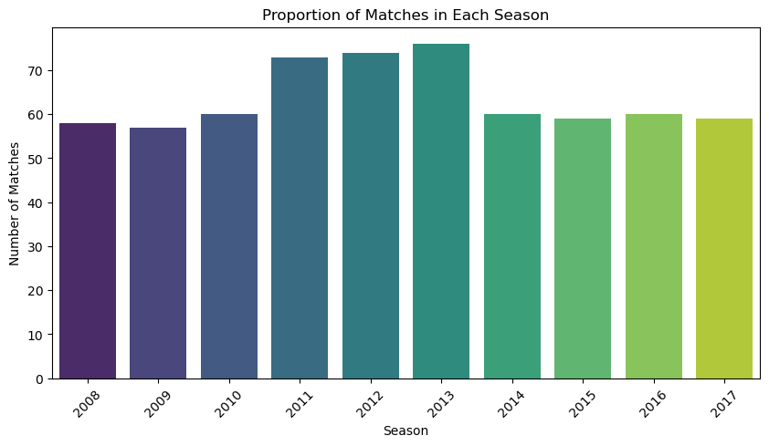

```python
# Question 1: Proportion of Number of matches in each Season
season_counts = df2['season'].value_counts().sort_index()
plt.figure(figsize=(10, 5))
sns.barplot(x=season_counts.index, y=season_counts.values, palette='viridis')
plt.xlabel('Season')
plt.ylabel('Number of Matches')
plt.title('Proportion of Matches in Each Season')
plt.xticks(rotation=45)
plt.show()
```

#### 2. Reason for Chart Type Selection:

The selected chart type is a bar chart. A bar chart is well-suited for displaying the count or frequency of categories (IPL seasons) in a categorical dataset. It allows for easy comparison of match counts across different seasons using the lengths of the bars.

#### 3. Pre-attentive Attributes:

##### Length:

The length of each bar represents the number of matches played in a specific season, allowing viewers to compare the match counts.

##### Color:

The color palette ('viridis') provides visual differentiation between the bars, making it easy to distinguish one season from another.

#### 4. Gestalt Principles:

##### Proximity:

Seasons with adjacent bars are visually grouped together, facilitating comparisons between consecutive years.

##### Continuity:

The continuous arrangement of bars along the x-axis creates a sense of continuity and helps viewers follow the progression of match counts from one season to the next.

### Question 2

#### Explore the proportion (percentage) of winning scores - win_by_runs, win_by_wickets for the entire time period from 2008 to 2019. Visualize using a single chart Write the python code in the below cell to create appropriate visual to perform the above task.

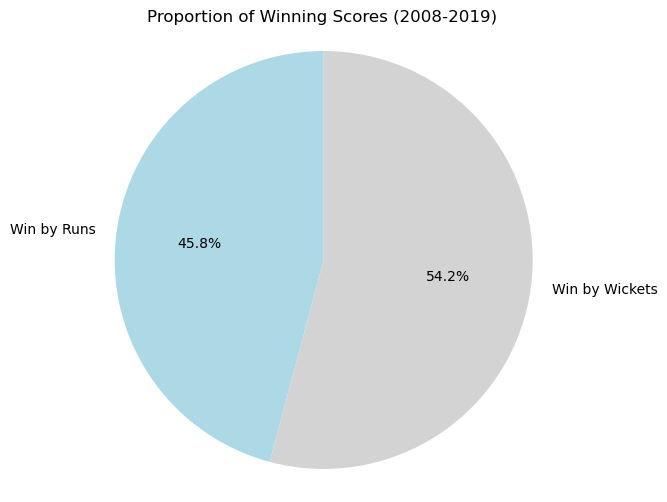

```python
# Filter the dataset to include matches from 2008 to 2019
matches_2008_to_2019 = df2[(df2['season'] >= 2008) & (df2['season'] <= 2019)]

# Calculate the total number of matches for each winning method
win_by_runs = matches_2008_to_2019[matches_2008_to_2019['win_by_runs'] > 0].shape[0]
win_by_wickets = matches_2008_to_2019[matches_2008_to_2019['win_by_wickets'] > 0].shape[0]


# Create a DataFrame for visualization
data = pd.DataFrame({'Winning Method': ['Win by Runs', 'Win by Wickets'],
                     'Count': [win_by_runs, win_by_wickets]})

# Create a pie chart
plt.figure(figsize=(6, 6))
plt.pie(data['Count'], labels=data['Winning Method'], autopct='%1.1f%%', colors=['lightblue', 'lightgrey'], startangle=90)
plt.title('Proportion of Winning Scores (2008-2019)')
plt.axis('equal')  # Equal aspect ratio ensures that pie is drawn as a circle.

plt.show()
```

#### 2. Reason for Chart Type Selection:

The selected chart type is a pie chart. A pie chart is suitable for displaying parts of a whole or proportions, making it effective for showing how different categories contribute to a total (in this case, the total number of matches won). It allows for a clear representation of the relative proportions of winning methods.

#### 3. Pre-attentive Attributes:

##### Area:

The size of each pie slice (sector) represents the proportion of matches won by a specific method. Viewers can quickly compare the areas of the slices to understand the distribution.

##### Color:

Different colors (light blue for "Win by Runs" and light grey for "Win by Wickets") are used to differentiate between the categories, aiding in visual separation.

#### 4. Gestalt Principles:

##### Closure:

The pie chart forms a closed shape, and viewers can perceive it as a whole. Each sector contributes to the complete circle, emphasizing the idea of the whole being divided into parts.

##### Continuity:

The continuous circular shape and radial lines extending from the center to the edges of each sector make it easy for viewers to trace and compare the segments.

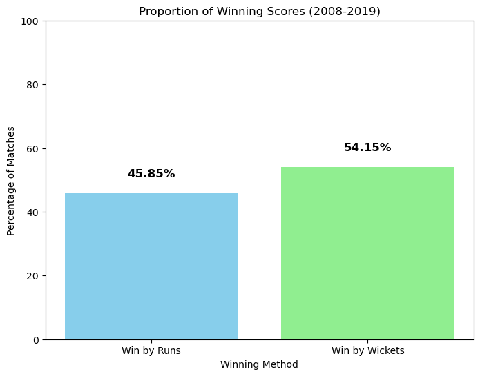

```python
# Filter matches from 2008 to 2019
matches_2008_to_2019 = df2[(df2['season'] >= 2008) & (df2['season'] <= 2019)]

# Calculate the count of matches won by runs and wickets
win_by_runs = matches_2008_to_2019[matches_2008_to_2019['win_by_runs'] > 0]
win_by_wickets = matches_2008_to_2019[matches_2008_to_2019['win_by_wickets'] > 0]

# Count the number of matches for each category
win_by_runs_count = len(win_by_runs)
win_by_wickets_count = len(win_by_wickets)
total_matches = win_by_runs_count + win_by_wickets_count #len(matches_2008_to_2019)

# Calculate the percentages
percentage_win_by_runs = (win_by_runs_count / total_matches) * 100
percentage_win_by_wickets = (win_by_wickets_count / total_matches) * 100

# Create a stacked bar chart
plt.figure(figsize=(8, 6))
plt.bar(['Win by Runs', 'Win by Wickets'], [percentage_win_by_runs, percentage_win_by_wickets], color=['skyblue', 'lightgreen'])
plt.xlabel('Winning Method')
plt.ylabel('Percentage of Matches')
plt.title('Proportion of Winning Scores (2008-2019)')
plt.ylim(0, 100)

# Display the percentages on the bars
for i, percentage in enumerate([percentage_win_by_runs, percentage_win_by_wickets]):
    plt.text(i, percentage + 5, f'{percentage:.2f}%', ha='center', fontsize=12, fontweight='bold')

plt.show()
```

#### 3. Pre-attentive Attributes:

##### Length:

The height of each bar segment represents the percentage of matches won by a specific method. Viewers can compare the lengths of the segments to understand the distribution.

##### Color:

Different colors (sky blue and light green) are used for the segments, aiding in visual separation and emphasizing the two categories.

#### 4. Gestalt Principles:

##### Continuity:

The continuous horizontal alignment of the segments and the positioning of the percentages on top of each segment create a sense of continuity and make it easy to follow and compare the proportions.

### Question 3

#### Perform a side by side visualization for the Toss Decisions, comparing the decision to field or bat across the period 2008-2019 in a single visual. Write the python code in the below cell to create appropriate visual to perform the above task.

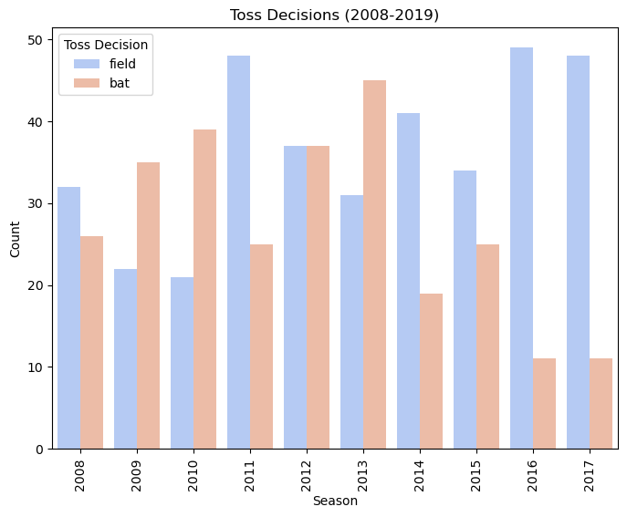

```python
toss_decisions = df2[(df2['season'] >= 2008) & (df2['season'] <= 2019)]['toss_decision']
plt.figure(figsize=(8, 6))
sns.countplot(data=df2[(df2['season'] >= 2008) & (df2['season'] <= 2019)], x='season', hue='toss_decision',palette='coolwarm')
plt.xlabel('Season')
plt.ylabel('Count')
plt.title('Toss Decisions (2008-2019)')
plt.legend(title='Toss Decision', loc='upper left')
plt.xticks(rotation=90)
plt.show()
```

#### 1. Findings:

The countplot visualizes the distribution of toss decisions (to bat or field) in IPL seasons from 2008 to 2019. It shows the number of times each decision was made in each season. The plot helps in understanding the trends in toss decisions over the specified time period.

#### 2. Reason for Chart Type Selection:

The selected chart type is a countplot with a hue (grouped bar chart). A countplot is suitable for visualizing the frequency or count of categorical data (toss decisions) across different categories (seasons). Using a hue separates the bars within each season by toss decision, making it easy to compare the counts for "bat" and "field" decisions in each season.

#### 3. Pre-attentive Attributes:

##### Length:

The length of the bars represents the count of toss decisions, allowing viewers to compare the frequency of "bat" and "field" decisions in each season.

##### Color:

The use of different colors for "bat" and "field" decisions (palette='coolwarm') provides visual differentiation and emphasizes the two categories.

#### 4. Gestalt Principles:

##### Similarity:

Bars of the same color within a season group together and convey the idea that they belong to the same category (toss decision).

##### Continuity:

The alignment of bars within each season and the grouping of bars by season make it easy to follow the trends and patterns in toss decisions over time.

Overall, the countplot effectively illustrates the distribution of toss decisions in IPL seasons from 2008 to 2019, highlighting any shifts or preferences for a particular decision type during this period.

### Question 4

#### Visualize the matches played by each team and find out which team played the maximum number of matches in IPL. Write the python code in the below cell to create appropriate visual to perform the above task.

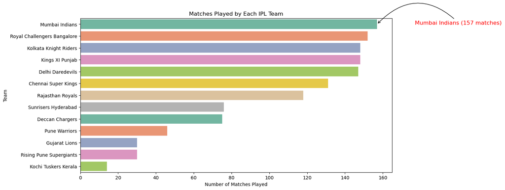

```python
# Concatenate team1 and team2 columns, and then count the number of matches played by each team
matches_played = pd.concat([df2['team1'], df2['team2']]).value_counts()

# Find the team that played the maximum number of matches
max_matches_team = matches_played.idxmax()
max_matches = matches_played[max_matches_team]

# Create a bar plot
plt.figure(figsize=(12, 6))
sns.barplot(x=matches_played.values, y=matches_played.index, palette='Set2')
plt.xlabel('Number of Matches Played')
plt.ylabel('Team')
plt.title('Matches Played by Each IPL Team')
plt.annotate(f"{max_matches_team} ({max_matches} matches)", xy=(max_matches, matches_played.index.get_loc(max_matches_team)), xytext=(max_matches + 20, matches_played.index.get_loc(max_matches_team)), arrowprops=dict(arrowstyle='->', connectionstyle='arc3,rad=0.5'), fontsize=12, color='red')
plt.xticks(rotation=0)
plt.show()
```

#### 3. Pre-attentive Attributes:

##### Position:

The position of the bars along the vertical axis represents different IPL teams, making it easy to compare the number of matches played by each team.

##### Color:

The color palette ('Set2') provides visual differentiation between bars representing different teams.

#### 4. Gestalt Principles:

##### Proximity:

Teams with similar numbers of matches played are grouped together on the chart, facilitating comparisons and identification of clusters of teams with similar participation levels.

##### Similarity:

The consistent use of colors for bars belonging to the same category (IPL teams) reinforces the idea that they are related.

### Question 5

#### Find out which venue had most number of matches played at. Plot the number of matches played at different venues and verify the same. Write the python code in the below cell to create the appropriate visual(single visual) to perform the above task .

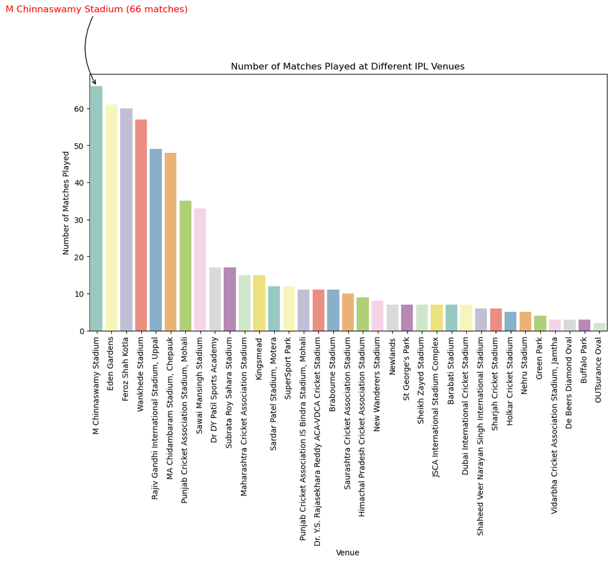

```python
# Count the number of matches played at each venue
venue_counts = df2['venue'].value_counts()

# Find the venue with the most number of matches
most_matches_venue = venue_counts.idxmax()
most_matches = venue_counts.iloc[0]

# Create a bar plot with swapped X and Y labels
plt.figure(figsize=(12, 6))
sns.barplot(x=venue_counts.index, y=venue_counts.values, palette='Set3')
plt.ylabel('Number of Matches Played')
plt.xlabel('Venue')
plt.title('Number of Matches Played at Different IPL Venues')

# Add text annotation for the venue with the most matches
plt.annotate(f"{most_matches_venue} ({most_matches} matches)", xy=(venue_counts.index.get_loc(most_matches_venue), most_matches), xytext=(venue_counts.index.get_loc(most_matches_venue), most_matches + 20), arrowprops=dict(arrowstyle='->', connectionstyle='arc3,rad=0.3'), fontsize=12, color='red', ha='center')

plt.xticks(rotation=90)  # Rotate X labels for better readability
plt.show()
```

#### 2. Reason for Chart Type Selection:

The selected chart type is a vertical bar plot (bar chart). A bar chart is suitable for displaying the count or frequency of categories (IPL venues) in a categorical dataset. Vertical bars are used to represent venues along the x-axis, and the length of each bar represents the number of matches played, making it easy to compare venues.

#### 3. Pre-attentive Attributes:

##### Position:

The position of the bars along the x-axis represents different IPL venues, allowing viewers to compare the number of matches played at each venue.

##### Color:

The color palette ('Set3') provides visual differentiation between the bars for different venues.

#### 4. Gestalt Principles:

##### Proximity:

Venues with similar numbers of matches played are grouped together on the chart, making it easier to identify clusters of venues with similar popularity.

##### Similarity:

The consistent use of colors for bars belonging to the same category (IPL venues) reinforces the idea that they are related.

Overall, the vertical bar plot effectively conveys information about the number of matches played at various IPL venues. It allows viewers to quickly identify the venue with the most matches and make comparisons between different venues in terms of match frequency.

# Group's choice - 2 Marks

#### Frame 1 (more) question which will help in the EDA(Exploratory Data Analysis) of the given data set and answer the same using the best visual.

1. Write the question in a markdown cell
2. Below the question, in a coding cell, write the python code to create the visual to answer the question

#### Answer in markdown cells below the visual 1.Summarise your findings from the visual. 2.The reason for selecting the chart type you did. 3.Mention the pre-attentive attributes used.(atleast 2) 4.Mention the gestalt principles used.(atleast 2)

#### Question : Find out the win/loss ratio of each teams and identify the team with highest win/loss ratio.

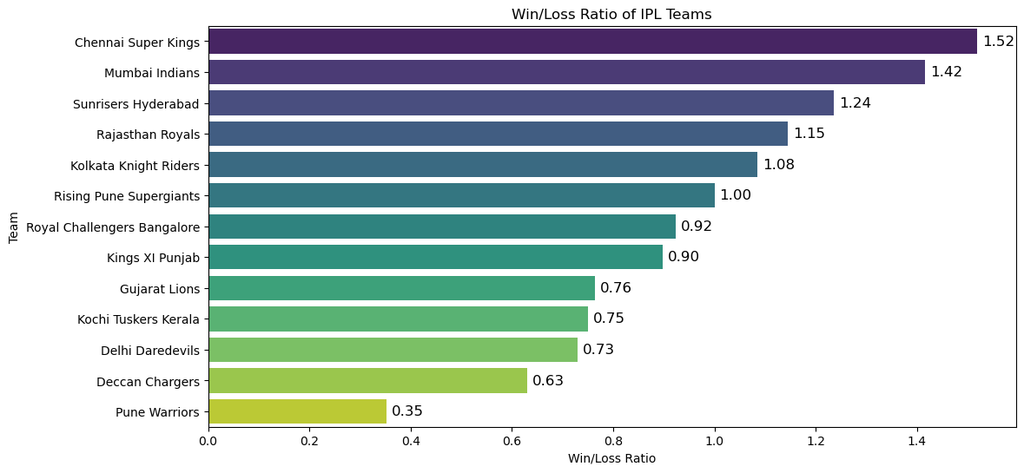

```python
# Calculate the number of wins for each team in dataset2
wins = df2['winner'].value_counts().reset_index()
wins.columns = ['Team', 'Wins']

# Calculate the number of matches played by each team in dataset2
matches_played = pd.concat([df2['team1'], df2['team2']]).value_counts().reset_index()
matches_played.columns = ['Team', 'Matches_Played']

# Merge wins and matches_played DataFrames
team_stats = pd.merge(wins, matches_played, on='Team', how='outer')

# Calculate the win/loss ratio while handling cases with zero wins or matches
team_stats['Win_Loss_Ratio'] = team_stats['Wins'] / (team_stats['Matches_Played'] - team_stats['Wins'])

# Sort the DataFrame by Win/Loss Ratio
team_stats = team_stats.sort_values(by='Win_Loss_Ratio', ascending=False)

# Create a bar plot for Win/Loss Ratio
plt.figure(figsize=(12, 6))
ax = sns.barplot(x='Win_Loss_Ratio', y='Team', data=team_stats, palette='viridis')
plt.xlabel('Win/Loss Ratio')
plt.ylabel('Team')
plt.title('Win/Loss Ratio of IPL Teams')
plt.xticks(rotation=0)

# Add Win/Loss Ratio values as text annotations on the bars
for i, ratio in enumerate(team_stats['Win_Loss_Ratio']):
    ax.text(ratio + 0.01, i, f'{ratio:.2f}', va='center', fontsize=12)

plt.show()
```

#### Chart Type Selection:

The chart type selected is a horizontal bar plot. Horizontal bar plots are suitable for comparing and ranking categories (IPL teams in this case) based on a continuous numerical variable (Win/Loss Ratio). The horizontal orientation allows for longer team names to be displayed without overlapping, improving readability.

#### Pre-attentive Attributes:

##### Position:

The position of the bars along the horizontal axis represents the Win/Loss Ratio, making it easy to compare teams' performance.

##### Color:

The color palette ('viridis') provides visual differentiation between bars, helping to distinguish one team from another.

#### Gestalt Principles:

##### Proximity:

Teams with similar Win/Loss Ratios are grouped together on the chart, allowing viewers to compare teams with similar performance.

##### Similarity:

The use of consistent colors for bars belonging to the same category (IPL team) reinforces the idea that they are related. Overall, the horizontal bar plot effectively communicates the Win/Loss Ratio of IPL teams, making it easy to identify the top-performing teams with higher ratios and the teams that may need improvement with lower ratios.